# Supplementary Materials

This document contains some extra bits of information to supplement the poster, as well as figures that just weren’t good enough to make it onto the final version of the poster.

## Retrieving data

Download zip files from the Wellcome Osteological Research Database (website currently not accessible).

Extract all files.

```bash
unzip "*.zip"
```

Rename files to .csv

```bash
for file in $(ls .)
    do
        mv $file $file".csv"
    done
```

## Importing data to R

Import all datasets containing relevant dental data into R using DuckDB.

```r
con <- dbConnect(duckdb::duckdb(), dbdir = ":memory:")
dental_inventory <- dbGetQuery(con, "SELECT * FROM read_csv('<path/to/folder>/*bones_present.lst.csv', delim = '|')")
dental_pathology <- dbGetQuery(con, "SELECT * FROM read_csv('<path/to/folder>/*dental_path.lst.csv', delim = '|')")
```

Total sample size: 1650

## Filtering dataset

Filtering the dataset to include adult individuals with permanent dentition only. It was also necessary to combine `SITECODE` (the code for the archaeological site) and `CONTEXT` (the unique identifier for individuals within each site), as `CONTEXT` was not unique for individuals across all sites. This was done by combining `SITECODE` and `CONTEXT`: `ID` = `SITECODE_CONTEXT`.

```r
dental_inventory |>
  filter(
    BONE_GP == "Permanent teeth",  # only dental data
    str_detect(AGE, "SUB-ADULT", negate = T) # only adults
  ) |>
  separate_wider_delim(
    BONES_PRESENT,
    delim = " ",
    names = c("region", "side", "type")
  ) |>
  mutate(
    region = case_match(
      region,
      "Maxilla" ~ "U",
      "Mandible" ~ "L"
    ),
    tooth = paste0(region, side, type),
    tooth = case_when(
      stringr::str_detect(tooth, "C$") ~ paste0(tooth, "1"), # add 1 to canine notation (e.g. ULC -> ULC1)
      TRUE ~ tooth
    )
  ) |>
    # create a unique identifier (some CONTEXT is repeated across sites)
  mutate(ID = paste0(SITECODE, "_", CONTEXT)) |>
  select(ID, tooth)
```

Sample sizes were calculated for the following samples:

adult individuals with complete dentitions (incl. M3s),

```r
# including M3s

dental_inventory_long |>
  group_by(ID) |>
  summarise(n_teeth = sum(presence)) |>
  filter(n_teeth == 32) |>
  nrow() # 567
```

```
[1] 567
```

adult individuals with complete dentitions AND all teeth scored for LEH lesions (incl. M3s),

```r
hypoplasia_long |>
  group_by(ID) |>
  summarise(leh_scores = sum(can_score)) |>
  filter(leh_scores == 32) |>
  nrow() # 12
```

```
[1] 12
```

and Adult individuals with complete dentitions AND all teeth scored for LEH lesions AND LEH lesion present on at least one tooth (incl. M3s).

```r
hypoplasia_long |>
  group_by(ID) |>
  summarise(
    leh_scores = sum(can_score),
    leh_bin = sum(leh_bin),
  ) |>
  filter(leh_scores == 32) |>
  filter(leh_bin > 0) |>
  nrow() # 7
```

```
[1] 7
```

The same counts as above, but excluding M3s.

Adult individuals with complete dentitions (excl. M3s),

```r
dental_inventory_long |>
  filter(!stringi::stri_detect(tooth, regex = "M3$")) |>
  group_by(ID) |>
  summarise(n_teeth = sum(presence)) |>
  filter(n_teeth == 28) |>
  nrow() # 708
```

```
[1] 708
```

```r
hypoplasia_long |>
  filter(!stringi::stri_detect(tooth, regex = "M3$")) |>
  group_by(ID) |>
  summarise(leh_scores = sum(can_score)) |>
  filter(leh_scores == 28) |>
  nrow() # 25
```

```
[1] 25
```

```r
hypoplasia_long |>
  filter(!stringi::stri_detect(tooth, regex = "M3$")) |>
  group_by(ID) |>
  summarise(
    leh_scores = sum(can_score),
    leh_bin = sum(leh_bin),
  ) |>
  filter(leh_scores == 28) |>
  filter(leh_bin > 0) |>
  nrow() # 16
```

```
[1] 16
```

Still not ideal sample sizes, but definitely an improvement over samples with M3s.

## Demographics

Sex and age distributions included for context. Given the low samples size of the LEH-positive sample, there was no sense in doing any analysis on sex and age.

```r
hypoplasia_long |>
  left_join(demography) |>
  distinct(ID, .keep_all = T) |>
  group_by(SEX, AGE) |>
  count(SEX, AGE) # |> _$n |> sum() # for sample size
```

Table 1: Demographics for the full sample (n = 1418).

| SEX | AGE | n |
| --- | --- | --- |
| FEMALE | ADULT 18-25 YEARS | 29 |
| FEMALE | ADULT 26-35 YEARS | 64 |
| FEMALE | ADULT 36-45 YEARS | 74 |
| FEMALE | ADULT >46 YEARS | 74 |
| FEMALE | UNCLASSIFIED ADULT | 6 |
| FEMALE? | ADULT 18-25 YEARS | 12 |
| FEMALE? | ADULT 26-35 YEARS | 25 |
| FEMALE? | ADULT 36-45 YEARS | 34 |
| FEMALE? | ADULT >46 YEARS | 23 |
| FEMALE? | UNCLASSIFIED ADULT | 10 |
| INTERMEDIATE | ADULT 18-25 YEARS | 7 |
| INTERMEDIATE | ADULT 26-35 YEARS | 15 |
| INTERMEDIATE | ADULT 36-45 YEARS | 14 |
| INTERMEDIATE | ADULT >46 YEARS | 13 |
| INTERMEDIATE | UNCLASSIFIED ADULT | 11 |
| MALE | ADULT 18-25 YEARS | 61 |
| MALE | ADULT 26-35 YEARS | 148 |
| MALE | ADULT 36-45 YEARS | 306 |
| MALE | ADULT >46 YEARS | 175 |
| MALE | UNCLASSIFIED ADULT | 50 |
| MALE? | ADULT 18-25 YEARS | 28 |
| MALE? | ADULT 26-35 YEARS | 60 |
| MALE? | ADULT 36-45 YEARS | 70 |
| MALE? | ADULT >46 YEARS | 26 |
| MALE? | UNCLASSIFIED ADULT | 54 |
| UNDETERMINABLE | ADULT 18-25 YEARS | 6 |
| UNDETERMINABLE | ADULT 26-35 YEARS | 5 |
| UNDETERMINABLE | ADULT 36-45 YEARS | 3 |
| UNDETERMINABLE | ADULT >46 YEARS | 2 |
| UNDETERMINABLE | UNCLASSIFIED ADULT | 13 |

```r
hypoplasia_present_long |>
  left_join(demography) |>
  distinct(ID, .keep_all = T) |>
  group_by(SEX, AGE) |>
  count(SEX, AGE) # |> _$n |> sum() # for sample size
```

Table 2: Demographics for the LEH-positive sample (n = 16).

| SEX | AGE | n |
| --- | --- | --- |
| FEMALE | ADULT 26-35 YEARS | 1 |
| INTERMEDIATE | ADULT 26-35 YEARS | 1 |
| MALE | ADULT 18-25 YEARS | 4 |
| MALE | ADULT 26-35 YEARS | 3 |
| MALE | ADULT 36-45 YEARS | 3 |
| MALE | ADULT >46 YEARS | 1 |
| MALE? | ADULT 26-35 YEARS | 1 |
| MALE? | ADULT 36-45 YEARS | 2 |

Figures, in case you don’t like tables.

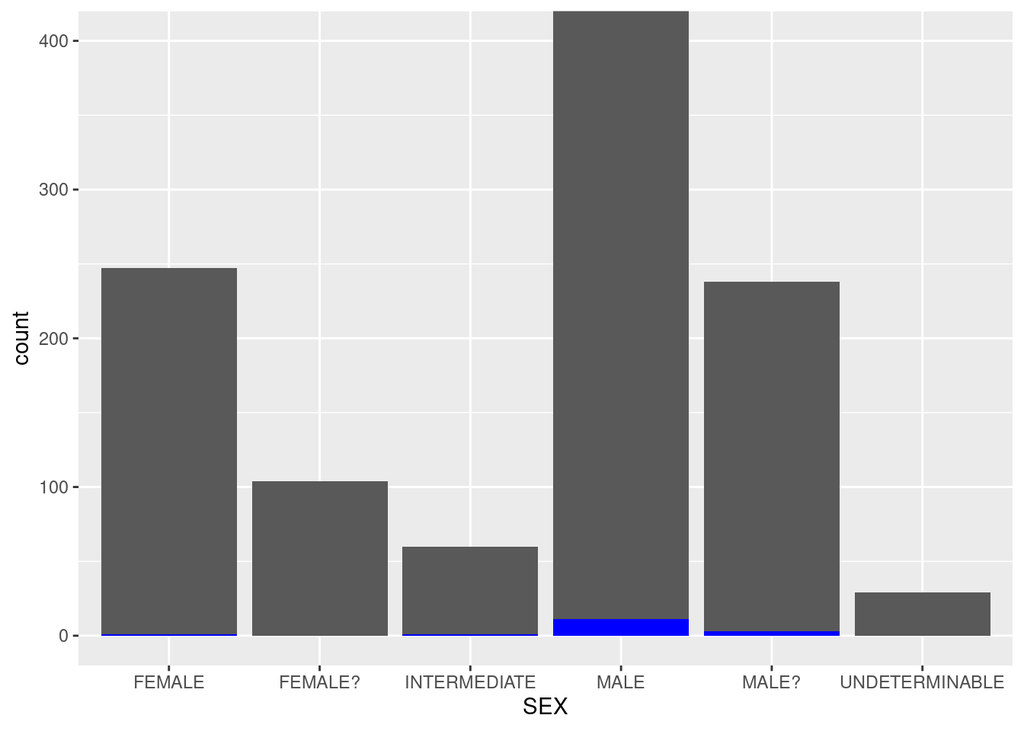

Figure 1: Distribution of sex in the full sample (charcoal; n = 1418) and the LEH-positive sample (blue; n = 16). Y-axis is cut off at 400 to be able to see the LEH-positive counts.

```r
# needs to be proportions?
hypoplasia_long |>
  left_join(demography) |>
  distinct(ID, .keep_all = T) |>
  mutate(leh_present = as_factor(leh_present)) |>
  ggplot(aes(x = SEX)) +
    geom_bar(position = "dodge") +
    # overlay lesions present sample
    geom_bar(data = distinct(left_join(hypoplasia_present_long, demography), ID, .keep_all = T), aes(x = SEX), fill = "blue") +
    coord_cartesian(ylim = c(0,400)) # cut y-axis off at 400
```

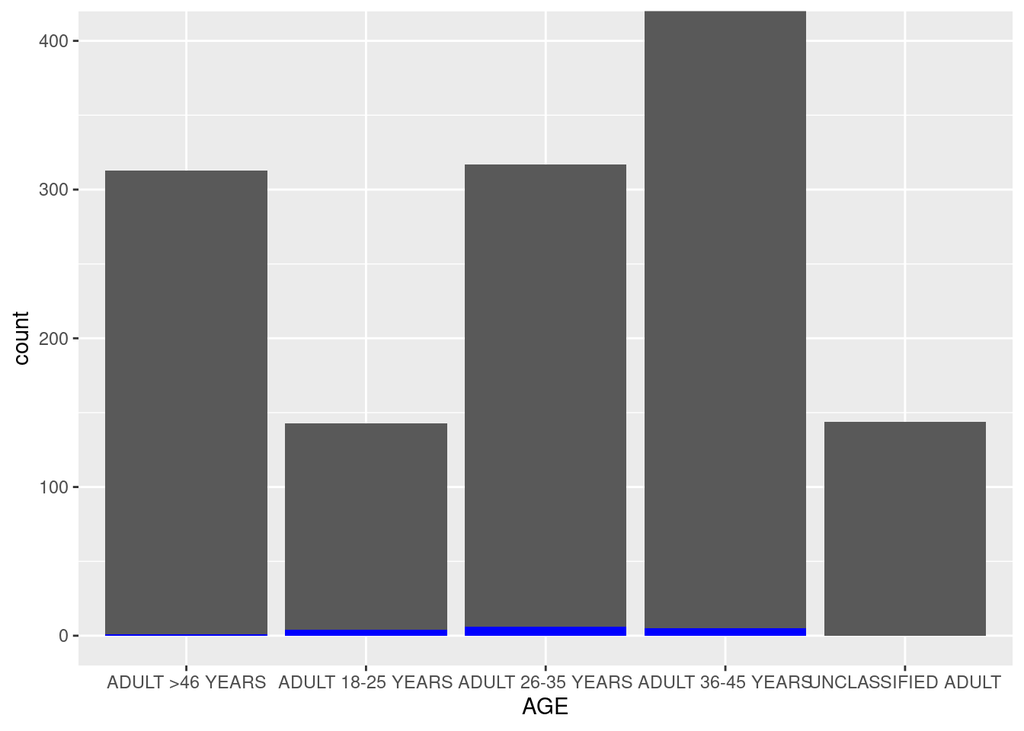

Figure 2: Distribution of age in the full sample (charcoal; n = 1418) and the LEH-positive sample (blue; n = 16). Y-axis is cut off at 400 to be able to see the LEH-positive counts.

```r
# needs to be proportions?
hypoplasia_long |>
  left_join(demography) |>
  distinct(ID, .keep_all = T) |>
  mutate(leh_present = as_factor(leh_present)) |>
  ggplot(aes(x = AGE)) +
    geom_bar(position = "dodge") +
    # overlay lesions present sample
    geom_bar(data = distinct(left_join(hypoplasia_present_long, demography), ID, .keep_all = T), aes(x = AGE), fill = "blue") +
    coord_cartesian(ylim = c(0,400)) # cut y-axis off at 400
```

## Key Results

Most of the analysis was done on the 16 individuals that have complete LEH scores in all teeth (except M3s), AND have at least one LEH lesion present (LEH-positive). The nine other individuals with complete scores but without any lesions are not useful in this analysis.

### (Missing) Data patterns

Adults with permanent dentition (excl. M3s) that were scored for LEH.

```r
nrow(distinct(hypoplasia_data, ID)) # number of individuals
```

```
[1] 1418
```

```r
na_pattern <- md.pattern(hypoplasia_data[,-1], plot = F)
nrow(na_pattern) - 1 # number of patterns
```

```
[1] 1248
```

Adults with a complete permanent dentition missing that were scored for LEH.

```r
# can_score
nrow(distinct(hypoplasia_complete_wide, ID)) # number of individuals
```

```
[1] 711
```

```r
leh_na_pattern <- md.pattern(hypoplasia_complete_wide[,-1], plot = F)
nrow(leh_na_pattern) - 1 # number of patterns
```

```
[1] 573
```

Before plotting missing data per individual, individuals with all teeth present and endentulous individuals were removed since they are not interesting (the former have no missing data and the later have only missing data). Then individuals were arranged by number of teeth,

```r
# number missing teeth per individual (to order heatmaps)
missing_ordered <- dental_inventory_long |>
  #mutate(presence = presence) |>
  group_by(ID) |>
  filter(type != "m3") |>
  summarise(n_teeth = sum(as.numeric(presence))) |>
  filter(
    n_teeth != 28 &
      n_teeth != 0 # endentulous and full dentitions are not informative
  ) |>
  arrange(desc(n_teeth))

dental_inventory_long <- dental_inventory_long |>
  mutate(presence = as_factor(presence))
```

and plotted, with maxillary and mandibular teeth displayed in separate plots.

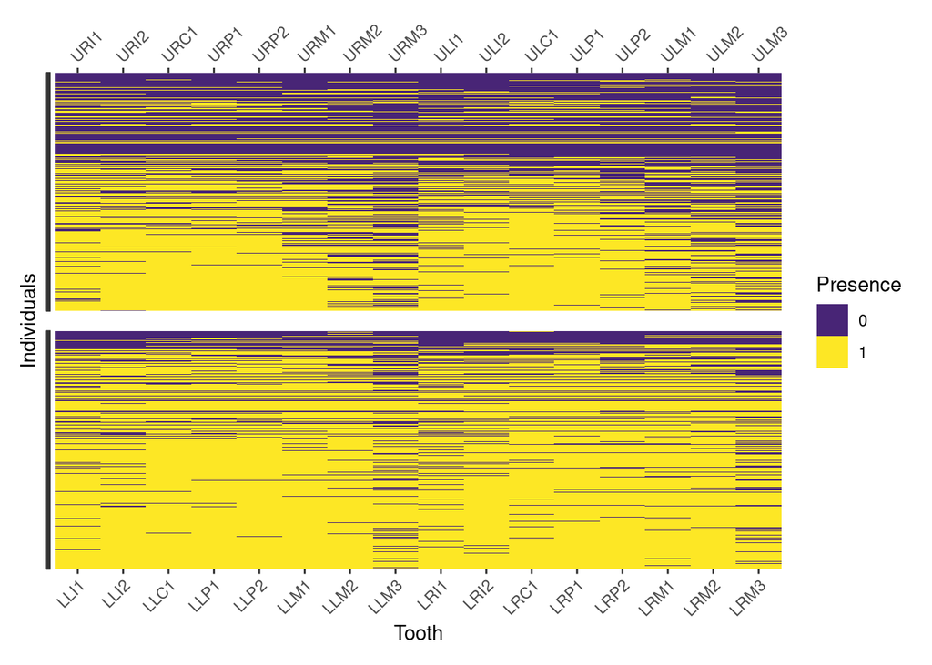

Figure 3: Heat Map of present and missing teeth for all adults with permanent dentition (n = 1650). Maxillary (top) and mandibular (bottom) teeth arranged according to position in the mouth.

```r
max_inventory_heat <- dental_inventory_long |>
  filter(
    region == "maxilla",
    ID %in% missing_ordered$ID
  ) |>
  mutate(ID = factor(ID, levels = missing_ordered$ID)) |>
  ggplot(aes(x = tooth, y = ID, fill = presence)) +
  geom_tile() +
  scale_x_discrete(position = "top", guide = guide_axis(angle = 45)) +
  theme(
    #axis.text.x.top = element_text(angle = 45, hjust = 0, vjust = 0),
    axis.text.y = element_blank(),
    axis.title.x = element_blank()
  )

man_inventory_heat <- dental_inventory_long |>
  filter(
    region == "mandible",
    ID %in% missing_ordered$ID
  ) |>
  mutate(ID = factor(ID, levels = missing_ordered$ID)) |>
  ggplot(aes(x = tooth, y = ID, fill = presence)) +
  geom_tile() +
  scale_x_discrete(position = "bottom", guide = guide_axis(angle = 45)) +
  theme(
    #axis.text.x = element_text(angle = 45, hjust = 1, vjust = 1),
    axis.text.y = element_blank()
  )

(max_inventory_heat / man_inventory_heat) +
  plot_layout(guides = "collect", axis_titles = "collect") &
  labs(x = "Tooth", y = "Individuals", fill = "Presence") &
  scale_fill_viridis_d(option = "viridis", begin = 0.1)
```

The same was done for hypoplasia scores. If a tooth could be scored, it received a score of 1, if not, it received a score of 0.

```r
scoreable_ordered <- hypoplasia_complete_long |>
  group_by(ID) |>
  filter(type != "m3") |>
  summarise(n_teeth = sum(as.numeric(can_score))) |>
  filter(
    n_teeth != 28 &
      n_teeth != 0 # endentulous and full dentitions are not informative
  ) |>
  arrange(desc(n_teeth))
```

Then separate heatmaps were made for maxillary and mandibular teeth.

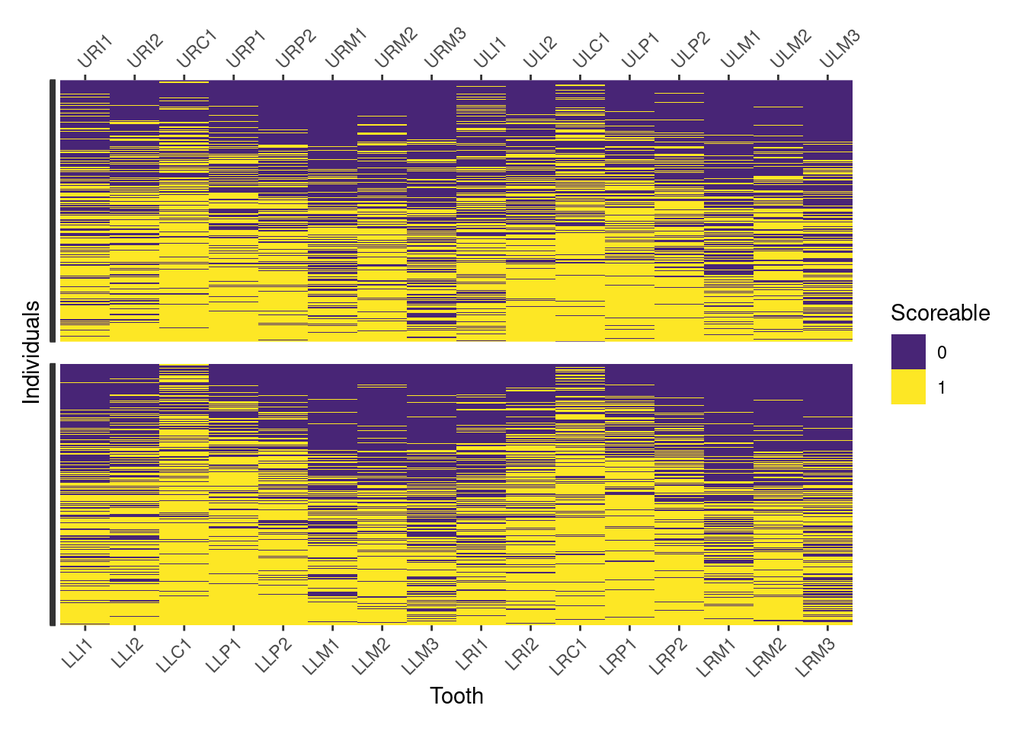

Figure 4: Heat Map of whether teeth could be scored for hypoplasia in the full sample (n = 1418). Maxillary (top) and mandibular (bottom) teeth arranged according to position in the mouth.

```r
max_scoreable_heat <- hypoplasia_complete_long |>
  filter(
    region == "maxilla",
    ID %in% scoreable_ordered$ID
  ) |>
  mutate(ID = factor(ID, levels = scoreable_ordered$ID)) |>
  ggplot(aes(x = tooth, y = ID, fill = as_factor(can_score))) +
  geom_tile() +
  scale_x_discrete(position = "top", guide = guide_axis(angle = 45)) +
  theme(
    #axis.text.x.top = element_text(angle = 45, hjust = 0, vjust = 0),
    axis.text.y = element_blank(),
    axis.title.x = element_blank()
  )

man_scoreable_heat <- hypoplasia_complete_long |>
  filter(
    region == "mandible",
    ID %in% scoreable_ordered$ID
  ) |>
  mutate(ID = factor(ID, levels = scoreable_ordered$ID)) |>
  ggplot(aes(x = tooth, y = ID, fill = as_factor(can_score))) +
  geom_tile() +
  scale_x_discrete(guide = guide_axis(angle = 45)) +
  theme(
    #axis.text.x.top = element_text(angle = 45, hjust = 0, vjust = 0),
    axis.text.y = element_blank(),
    #axis.title.x = element_blank()
  )

(max_scoreable_heat / man_scoreable_heat) +
  plot_layout(guides = "collect", axis_titles = "collect") &
  labs(x = "Tooth", y = "Individuals", fill = "Scoreable") &
  scale_fill_viridis_d(option = "viridis", begin = 0.1)
```

### LEH lesion patterns

To explore patterns of the presence and absence of LEH using the `mice` package, scores of 0, i.e. absence of a lesion, were converted to `NA`.

```r
hypoplasia_present_wide <- hypoplasia_present_long |>
  select(ID, tooth, score) |>
  mutate(score = if_else(score == 0, NA, 1)) |>
  pivot_wider(names_from = "tooth", values_from = "score")
```

This allowed us to use the missing data functions on the hypoplasia scores to explore score patterns, which was done on the LEH-positive sample (n = 16).

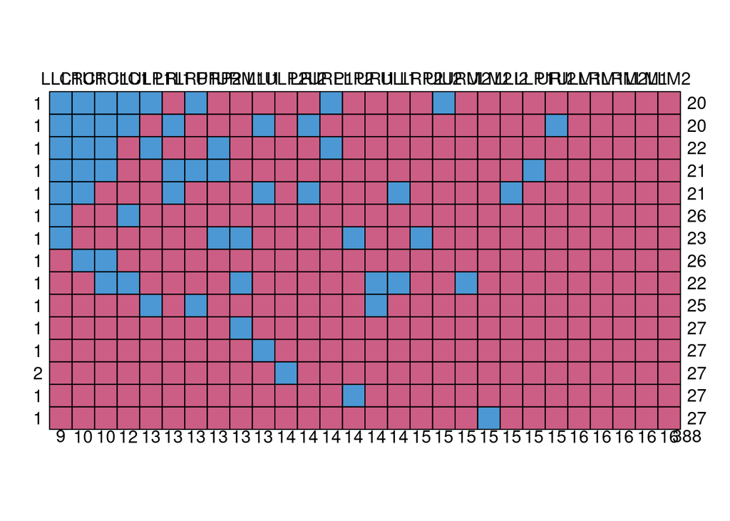

Figure 5: Pattern of scores in the LEH-positive sample. Each row represents a different pattern of scores. Row names is the number of times the pattern occurs in the sample.

```r
leh_score_pattern <- md.pattern(hypoplasia_present_wide[,-1])
```

Number of patterns: 15

Number of insults per tooth, tooth type, and tooth class in the LEH-positive sample. Calculated as the number of affected teeth divided by the number of teeth present in the sample.

```r
# tooth
hypoplasia_present_long |>
  group_by(tooth) |>
  summarise(
    n = n(),
    present = sum(leh_bin),
    .groups = "keep"
  ) |>
  mutate(prop = present / n) |>
  arrange(desc(prop))
# tooth type
hypoplasia_present_long |>
  group_by(type) |>
  summarise(
    n = n(),
    present = sum(leh_bin),
    .groups = "keep"
  ) |>
  mutate(prop = present / n) |>
  arrange(desc(prop))
# tooth class
hypoplasia_present_long |>
  group_by(class) |>
  summarise(
    n = n(),
    present = sum(leh_bin),
    .groups = "keep"
  ) |>
  mutate(prop = present / n) |>
  arrange(desc(prop))
```

Table 3: Ratios of LEH per tooth, tooth type, and tooth class, respectively, in the LEH-positive sample.

(a) Ratio per tooth

| tooth | n | present | prop |
| --- | --- | --- | --- |
| LLC1 | 16 | 7 | 0.4375 |
| URC1 | 16 | 6 | 0.3750 |
| LRC1 | 16 | 6 | 0.3750 |
| ULC1 | 16 | 4 | 0.2500 |
| URP2 | 16 | 3 | 0.1875 |
| URM1 | 16 | 3 | 0.1875 |
| ULP1 | 16 | 3 | 0.1875 |
| LLI1 | 16 | 3 | 0.1875 |
| LRI1 | 16 | 3 | 0.1875 |
| LRP1 | 16 | 3 | 0.1875 |
| URI1 | 16 | 2 | 0.1250 |
| URP1 | 16 | 2 | 0.1250 |
| ULI1 | 16 | 2 | 0.1250 |
| ULP2 | 16 | 2 | 0.1250 |
| LLP2 | 16 | 2 | 0.1250 |
| LRI2 | 16 | 2 | 0.1250 |
| URI2 | 16 | 1 | 0.0625 |
| URM2 | 16 | 1 | 0.0625 |
| ULI2 | 16 | 1 | 0.0625 |
| ULM2 | 16 | 1 | 0.0625 |
| LLI2 | 16 | 1 | 0.0625 |
| LLP1 | 16 | 1 | 0.0625 |
| LRP2 | 16 | 1 | 0.0625 |
| ULM1 | 16 | 0 | 0.0000 |
| LLM1 | 16 | 0 | 0.0000 |
| LLM2 | 16 | 0 | 0.0000 |
| LRM1 | 16 | 0 | 0.0000 |
| LRM2 | 16 | 0 | 0.0000 |

(b) Ratio per tooth type

| type | n | present | prop |
| --- | --- | --- | --- |
| c | 64 | 23 | 0.359375 |
| i1 | 64 | 10 | 0.156250 |
| pm1 | 64 | 9 | 0.140625 |
| pm2 | 64 | 8 | 0.125000 |
| i2 | 64 | 5 | 0.078125 |
| m1 | 64 | 3 | 0.046875 |
| m2 | 64 | 2 | 0.031250 |

(c) Ratio per tooth class

| class | n | present | prop |
| --- | --- | --- | --- |
| canine | 64 | 23 | 0.3593750 |
| premolar | 128 | 17 | 0.1328125 |
| incisor | 128 | 15 | 0.1171875 |
| molar | 128 | 5 | 0.0390625 |

```r
# Convert scores of 0 to NA
hypoplasia_present_na <- hypoplasia_present_wide |>
  mutate(across(-ID, \(x) if_else(x == 0, NA, x)))

score_pairs <- md.pairs(hypoplasia_present_na[,-1])
```

```r
score_pairs$rr |>
  as_tibble(rownames = "tooth")
```

Table 4: Counts of teeth with an LEH ‘present’ score in the LEH-positive sample.

| tooth | ULC1 | ULP1 | ULP2 | ULM1 | LRI1 | LRI2 | LRC1 | LRP1 | LRP2 | LRM1 | LRM2 | ULI2 | URP1 | URP2 | URM1 | URM2 | ULM2 | LLI1 | LLI2 | LLC1 | LLP1 | LLP2 | LLM1 | LLM2 | URC1 | URI1 | URI2 | ULI1 |
| --- | --- | --- | --- | --- | --- | --- | --- | --- | --- | --- | --- | --- | --- | --- | --- | --- | --- | --- | --- | --- | --- | --- | --- | --- | --- | --- | --- | --- |
| ULC1 | 4 | 1 | 0 | 0 | 1 | 1 | 2 | 1 | 0 | 0 | 0 | 1 | 1 | 0 | 1 | 1 | 0 | 1 | 0 | 3 | 0 | 0 | 0 | 0 | 3 | 1 | 1 | 1 |
| ULP1 | 1 | 3 | 0 | 0 | 0 | 0 | 2 | 2 | 0 | 0 | 0 | 1 | 2 | 1 | 0 | 0 | 0 | 0 | 0 | 2 | 0 | 0 | 0 | 0 | 2 | 1 | 0 | 0 |
| ULP2 | 0 | 0 | 2 | 0 | 0 | 0 | 0 | 0 | 0 | 0 | 0 | 0 | 0 | 0 | 0 | 0 | 0 | 0 | 0 | 0 | 0 | 0 | 0 | 0 | 0 | 0 | 0 | 0 |
| ULM1 | 0 | 0 | 0 | 0 | 0 | 0 | 0 | 0 | 0 | 0 | 0 | 0 | 0 | 0 | 0 | 0 | 0 | 0 | 0 | 0 | 0 | 0 | 0 | 0 | 0 | 0 | 0 | 0 |
| LRI1 | 1 | 0 | 0 | 0 | 3 | 2 | 3 | 1 | 0 | 0 | 0 | 0 | 0 | 1 | 0 | 0 | 0 | 2 | 1 | 3 | 1 | 0 | 0 | 0 | 2 | 0 | 1 | 1 |
| LRI2 | 1 | 0 | 0 | 0 | 2 | 2 | 2 | 0 | 0 | 0 | 0 | 0 | 0 | 0 | 0 | 0 | 0 | 2 | 1 | 2 | 0 | 0 | 0 | 0 | 1 | 0 | 1 | 1 |
| LRC1 | 2 | 2 | 0 | 0 | 3 | 2 | 6 | 2 | 0 | 0 | 0 | 1 | 2 | 2 | 0 | 0 | 0 | 2 | 1 | 5 | 1 | 0 | 0 | 0 | 5 | 0 | 1 | 1 |
| LRP1 | 1 | 2 | 0 | 0 | 1 | 0 | 2 | 3 | 0 | 0 | 0 | 1 | 1 | 1 | 0 | 0 | 0 | 0 | 0 | 2 | 1 | 0 | 0 | 0 | 2 | 1 | 0 | 0 |
| LRP2 | 0 | 0 | 0 | 0 | 0 | 0 | 0 | 0 | 1 | 0 | 0 | 0 | 0 | 1 | 1 | 0 | 0 | 0 | 0 | 1 | 0 | 1 | 0 | 0 | 0 | 0 | 0 | 0 |
| LRM1 | 0 | 0 | 0 | 0 | 0 | 0 | 0 | 0 | 0 | 0 | 0 | 0 | 0 | 0 | 0 | 0 | 0 | 0 | 0 | 0 | 0 | 0 | 0 | 0 | 0 | 0 | 0 | 0 |
| LRM2 | 0 | 0 | 0 | 0 | 0 | 0 | 0 | 0 | 0 | 0 | 0 | 0 | 0 | 0 | 0 | 0 | 0 | 0 | 0 | 0 | 0 | 0 | 0 | 0 | 0 | 0 | 0 | 0 |
| ULI2 | 1 | 1 | 0 | 0 | 0 | 0 | 1 | 1 | 0 | 0 | 0 | 1 | 1 | 0 | 0 | 0 | 0 | 0 | 0 | 1 | 0 | 0 | 0 | 0 | 1 | 0 | 0 | 0 |
| URP1 | 1 | 2 | 0 | 0 | 0 | 0 | 2 | 1 | 0 | 0 | 0 | 1 | 2 | 1 | 0 | 0 | 0 | 0 | 0 | 2 | 0 | 0 | 0 | 0 | 2 | 0 | 0 | 0 |
| URP2 | 0 | 1 | 0 | 0 | 1 | 0 | 2 | 1 | 1 | 0 | 0 | 0 | 1 | 3 | 1 | 0 | 0 | 0 | 0 | 3 | 1 | 1 | 0 | 0 | 2 | 0 | 0 | 0 |
| URM1 | 1 | 0 | 0 | 0 | 0 | 0 | 0 | 0 | 1 | 0 | 0 | 0 | 0 | 1 | 3 | 1 | 0 | 0 | 0 | 1 | 0 | 1 | 0 | 0 | 1 | 1 | 0 | 1 |
| URM2 | 1 | 0 | 0 | 0 | 0 | 0 | 0 | 0 | 0 | 0 | 0 | 0 | 0 | 0 | 1 | 1 | 0 | 0 | 0 | 0 | 0 | 0 | 0 | 0 | 1 | 1 | 0 | 1 |
| ULM2 | 0 | 0 | 0 | 0 | 0 | 0 | 0 | 0 | 0 | 0 | 0 | 0 | 0 | 0 | 0 | 0 | 1 | 0 | 0 | 0 | 0 | 0 | 0 | 0 | 0 | 0 | 0 | 0 |
| LLI1 | 1 | 0 | 0 | 0 | 2 | 2 | 2 | 0 | 0 | 0 | 0 | 0 | 0 | 0 | 0 | 0 | 0 | 3 | 1 | 2 | 0 | 0 | 0 | 0 | 1 | 0 | 1 | 1 |
| LLI2 | 0 | 0 | 0 | 0 | 1 | 1 | 1 | 0 | 0 | 0 | 0 | 0 | 0 | 0 | 0 | 0 | 0 | 1 | 1 | 1 | 0 | 0 | 0 | 0 | 0 | 0 | 0 | 1 |
| LLC1 | 3 | 2 | 0 | 0 | 3 | 2 | 5 | 2 | 1 | 0 | 0 | 1 | 2 | 3 | 1 | 0 | 0 | 2 | 1 | 7 | 1 | 1 | 0 | 0 | 4 | 0 | 1 | 1 |
| LLP1 | 0 | 0 | 0 | 0 | 1 | 0 | 1 | 1 | 0 | 0 | 0 | 0 | 0 | 1 | 0 | 0 | 0 | 0 | 0 | 1 | 1 | 0 | 0 | 0 | 1 | 0 | 0 | 0 |
| LLP2 | 0 | 0 | 0 | 0 | 0 | 0 | 0 | 0 | 1 | 0 | 0 | 0 | 0 | 1 | 1 | 0 | 0 | 0 | 0 | 1 | 0 | 2 | 0 | 0 | 0 | 0 | 0 | 0 |
| LLM1 | 0 | 0 | 0 | 0 | 0 | 0 | 0 | 0 | 0 | 0 | 0 | 0 | 0 | 0 | 0 | 0 | 0 | 0 | 0 | 0 | 0 | 0 | 0 | 0 | 0 | 0 | 0 | 0 |
| LLM2 | 0 | 0 | 0 | 0 | 0 | 0 | 0 | 0 | 0 | 0 | 0 | 0 | 0 | 0 | 0 | 0 | 0 | 0 | 0 | 0 | 0 | 0 | 0 | 0 | 0 | 0 | 0 | 0 |
| URC1 | 3 | 2 | 0 | 0 | 2 | 1 | 5 | 2 | 0 | 0 | 0 | 1 | 2 | 2 | 1 | 1 | 0 | 1 | 0 | 4 | 1 | 0 | 0 | 0 | 6 | 1 | 1 | 1 |
| URI1 | 1 | 1 | 0 | 0 | 0 | 0 | 0 | 1 | 0 | 0 | 0 | 0 | 0 | 0 | 1 | 1 | 0 | 0 | 0 | 0 | 0 | 0 | 0 | 0 | 1 | 2 | 0 | 1 |
| URI2 | 1 | 0 | 0 | 0 | 1 | 1 | 1 | 0 | 0 | 0 | 0 | 0 | 0 | 0 | 0 | 0 | 0 | 1 | 0 | 1 | 0 | 0 | 0 | 0 | 1 | 0 | 1 | 0 |
| ULI1 | 1 | 0 | 0 | 0 | 1 | 1 | 1 | 0 | 0 | 0 | 0 | 0 | 0 | 0 | 1 | 1 | 0 | 1 | 1 | 1 | 0 | 0 | 0 | 0 | 1 | 1 | 0 | 2 |

```r
score_pairs$mm |>
  as_tibble(rownames = "tooth")
```

Table 5: Counts of teeth with an LEH ‘absent’ score in the LEH-positive sample.

| tooth | ULC1 | ULP1 | ULP2 | ULM1 | LRI1 | LRI2 | LRC1 | LRP1 | LRP2 | LRM1 | LRM2 | ULI2 | URP1 | URP2 | URM1 | URM2 | ULM2 | LLI1 | LLI2 | LLC1 | LLP1 | LLP2 | LLM1 | LLM2 | URC1 | URI1 | URI2 | ULI1 |
| --- | --- | --- | --- | --- | --- | --- | --- | --- | --- | --- | --- | --- | --- | --- | --- | --- | --- | --- | --- | --- | --- | --- | --- | --- | --- | --- | --- | --- |
| ULC1 | 12 | 10 | 10 | 12 | 10 | 11 | 8 | 10 | 11 | 12 | 12 | 12 | 11 | 9 | 10 | 12 | 11 | 10 | 11 | 8 | 11 | 10 | 12 | 12 | 9 | 11 | 12 | 11 |
| ULP1 | 10 | 13 | 11 | 13 | 10 | 11 | 9 | 12 | 12 | 13 | 13 | 13 | 13 | 11 | 10 | 12 | 12 | 10 | 12 | 8 | 12 | 11 | 13 | 13 | 9 | 12 | 12 | 11 |
| ULP2 | 10 | 11 | 14 | 14 | 11 | 12 | 8 | 11 | 13 | 14 | 14 | 13 | 12 | 11 | 11 | 13 | 13 | 11 | 13 | 7 | 13 | 12 | 14 | 14 | 8 | 12 | 13 | 12 |
| ULM1 | 12 | 13 | 14 | 16 | 13 | 14 | 10 | 13 | 15 | 16 | 16 | 15 | 14 | 13 | 13 | 15 | 15 | 13 | 15 | 9 | 15 | 14 | 16 | 16 | 10 | 14 | 15 | 14 |
| LRI1 | 10 | 10 | 11 | 13 | 13 | 13 | 10 | 11 | 12 | 13 | 13 | 12 | 11 | 11 | 10 | 12 | 12 | 12 | 13 | 9 | 13 | 11 | 13 | 13 | 9 | 11 | 13 | 12 |
| LRI2 | 11 | 11 | 12 | 14 | 13 | 14 | 10 | 11 | 13 | 14 | 14 | 13 | 12 | 11 | 11 | 13 | 13 | 13 | 14 | 9 | 13 | 12 | 14 | 14 | 9 | 12 | 14 | 13 |
| LRC1 | 8 | 9 | 8 | 10 | 10 | 10 | 10 | 9 | 9 | 10 | 10 | 10 | 10 | 9 | 7 | 9 | 9 | 9 | 10 | 8 | 10 | 8 | 10 | 10 | 9 | 8 | 10 | 9 |
| LRP1 | 10 | 12 | 11 | 13 | 11 | 11 | 9 | 13 | 12 | 13 | 13 | 13 | 12 | 11 | 10 | 12 | 12 | 10 | 12 | 8 | 13 | 11 | 13 | 13 | 9 | 12 | 12 | 11 |
| LRP2 | 11 | 12 | 13 | 15 | 12 | 13 | 9 | 12 | 15 | 15 | 15 | 14 | 13 | 13 | 13 | 14 | 14 | 12 | 14 | 9 | 14 | 14 | 15 | 15 | 9 | 13 | 14 | 13 |
| LRM1 | 12 | 13 | 14 | 16 | 13 | 14 | 10 | 13 | 15 | 16 | 16 | 15 | 14 | 13 | 13 | 15 | 15 | 13 | 15 | 9 | 15 | 14 | 16 | 16 | 10 | 14 | 15 | 14 |
| LRM2 | 12 | 13 | 14 | 16 | 13 | 14 | 10 | 13 | 15 | 16 | 16 | 15 | 14 | 13 | 13 | 15 | 15 | 13 | 15 | 9 | 15 | 14 | 16 | 16 | 10 | 14 | 15 | 14 |
| ULI2 | 12 | 13 | 13 | 15 | 12 | 13 | 10 | 13 | 14 | 15 | 15 | 15 | 14 | 12 | 12 | 14 | 14 | 12 | 14 | 9 | 14 | 13 | 15 | 15 | 10 | 13 | 14 | 13 |
| URP1 | 11 | 13 | 12 | 14 | 11 | 12 | 10 | 12 | 13 | 14 | 14 | 14 | 14 | 12 | 11 | 13 | 13 | 11 | 13 | 9 | 13 | 12 | 14 | 14 | 10 | 12 | 13 | 12 |
| URP2 | 9 | 11 | 11 | 13 | 11 | 11 | 9 | 11 | 13 | 13 | 13 | 12 | 12 | 13 | 11 | 12 | 12 | 10 | 12 | 9 | 13 | 12 | 13 | 13 | 9 | 11 | 12 | 11 |
| URM1 | 10 | 10 | 11 | 13 | 10 | 11 | 7 | 10 | 13 | 13 | 13 | 12 | 11 | 11 | 13 | 13 | 12 | 10 | 12 | 7 | 12 | 12 | 13 | 13 | 8 | 12 | 12 | 12 |
| URM2 | 12 | 12 | 13 | 15 | 12 | 13 | 9 | 12 | 14 | 15 | 15 | 14 | 13 | 12 | 13 | 15 | 14 | 12 | 14 | 8 | 14 | 13 | 15 | 15 | 10 | 14 | 14 | 14 |
| ULM2 | 11 | 12 | 13 | 15 | 12 | 13 | 9 | 12 | 14 | 15 | 15 | 14 | 13 | 12 | 12 | 14 | 15 | 12 | 14 | 8 | 14 | 13 | 15 | 15 | 9 | 13 | 14 | 13 |
| LLI1 | 10 | 10 | 11 | 13 | 12 | 13 | 9 | 10 | 12 | 13 | 13 | 12 | 11 | 10 | 10 | 12 | 12 | 13 | 13 | 8 | 12 | 11 | 13 | 13 | 8 | 11 | 13 | 12 |
| LLI2 | 11 | 12 | 13 | 15 | 13 | 14 | 10 | 12 | 14 | 15 | 15 | 14 | 13 | 12 | 12 | 14 | 14 | 13 | 15 | 9 | 14 | 13 | 15 | 15 | 9 | 13 | 14 | 14 |
| LLC1 | 8 | 8 | 7 | 9 | 9 | 9 | 8 | 8 | 9 | 9 | 9 | 9 | 9 | 9 | 7 | 8 | 8 | 8 | 9 | 9 | 9 | 8 | 9 | 9 | 7 | 7 | 9 | 8 |
| LLP1 | 11 | 12 | 13 | 15 | 13 | 13 | 10 | 13 | 14 | 15 | 15 | 14 | 13 | 13 | 12 | 14 | 14 | 12 | 14 | 9 | 15 | 13 | 15 | 15 | 10 | 13 | 14 | 13 |
| LLP2 | 10 | 11 | 12 | 14 | 11 | 12 | 8 | 11 | 14 | 14 | 14 | 13 | 12 | 12 | 12 | 13 | 13 | 11 | 13 | 8 | 13 | 14 | 14 | 14 | 8 | 12 | 13 | 12 |
| LLM1 | 12 | 13 | 14 | 16 | 13 | 14 | 10 | 13 | 15 | 16 | 16 | 15 | 14 | 13 | 13 | 15 | 15 | 13 | 15 | 9 | 15 | 14 | 16 | 16 | 10 | 14 | 15 | 14 |
| LLM2 | 12 | 13 | 14 | 16 | 13 | 14 | 10 | 13 | 15 | 16 | 16 | 15 | 14 | 13 | 13 | 15 | 15 | 13 | 15 | 9 | 15 | 14 | 16 | 16 | 10 | 14 | 15 | 14 |
| URC1 | 9 | 9 | 8 | 10 | 9 | 9 | 9 | 9 | 9 | 10 | 10 | 10 | 10 | 9 | 8 | 10 | 9 | 8 | 9 | 7 | 10 | 8 | 10 | 10 | 10 | 9 | 10 | 9 |
| URI1 | 11 | 12 | 12 | 14 | 11 | 12 | 8 | 12 | 13 | 14 | 14 | 13 | 12 | 11 | 12 | 14 | 13 | 11 | 13 | 7 | 13 | 12 | 14 | 14 | 9 | 14 | 13 | 13 |
| URI2 | 12 | 12 | 13 | 15 | 13 | 14 | 10 | 12 | 14 | 15 | 15 | 14 | 13 | 12 | 12 | 14 | 14 | 13 | 14 | 9 | 14 | 13 | 15 | 15 | 10 | 13 | 15 | 13 |
| ULI1 | 11 | 11 | 12 | 14 | 12 | 13 | 9 | 11 | 13 | 14 | 14 | 13 | 12 | 11 | 12 | 14 | 13 | 12 | 14 | 8 | 13 | 12 | 14 | 14 | 9 | 13 | 13 | 14 |

(A)Symmetry in LEH insults.

Symmetry was calculated as agreement between tooth isomeres and antimeres, i.e., if either both teeth (in an antimere or isomere pair) had a lesion or had no lesion, this was considered agreement.

```r
isomere_score_agreement <- hypoplasia_present_long |> # symmetry is not informative on individuals with no lesions
  group_by(ID, side, type) |> # group by side to compare isomeres
  summarise(
    n = n(), # sanity check
    score = sum(leh_bin)
  ) |>
  mutate(
    agree = if_else(score == 1, FALSE, TRUE)
  ) |>
  ungroup()

# antimere symmetry

antimere_score_agreement <- hypoplasia_present_long |>
  group_by(ID, region, type) |> # group by region to compare antimeres
  summarise(
    n = n(), # sanity check
    score = sum(leh_bin)
  ) |>
  mutate(
    agree = if_else(score == 1, FALSE, TRUE)
  ) |>
  ungroup()
```

Plots

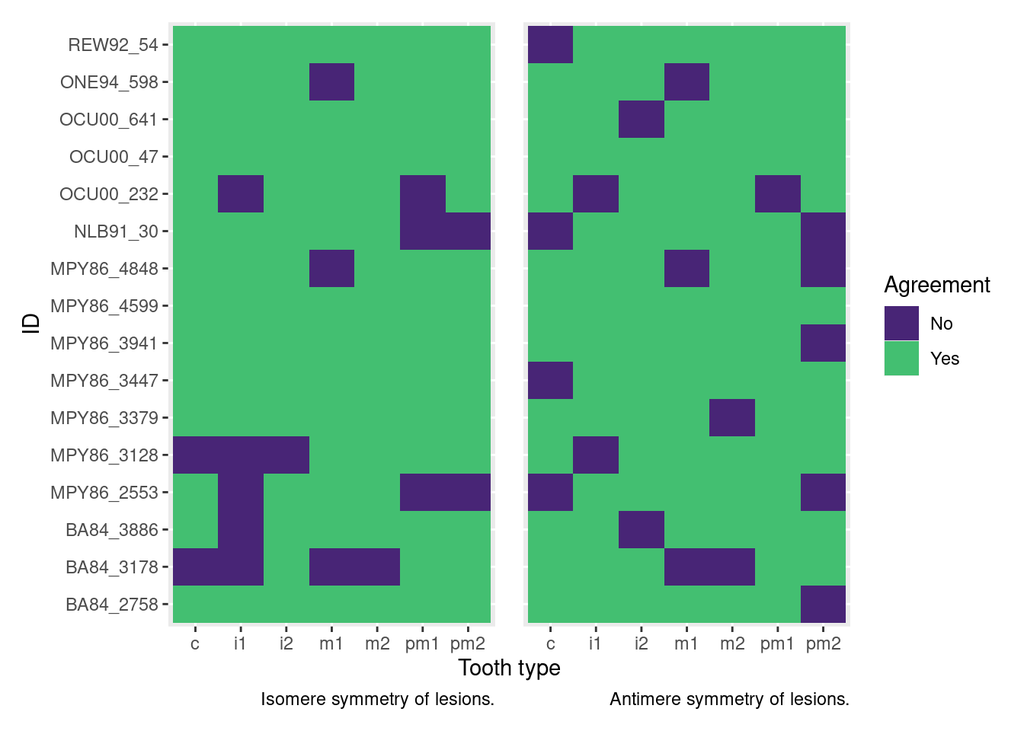

```r
isomere_symm_plot <- isomere_score_agreement |>
  ggplot(aes(x = type, y = ID, fill = agree)) +
    geom_tile() +
    labs(caption = "Isomere symmetry of lesions.")

antimere_symm_plot <- antimere_score_agreement |>
  ggplot(aes(x = type, y = ID, fill = agree)) +
    geom_tile() +
    labs(caption = "Antimere symmetry of lesions.") +
    theme(
      axis.text.y = element_blank(),
      axis.ticks.y = element_blank()
    )

isomere_symm_plot + antimere_symm_plot + plot_layout(guides = "collect", axis_titles = "collect") & labs(x = "Tooth type", fill = "Agreement") & scale_fill_manual(labels = c("No", "Yes"), values = viridisLite::viridis(2, begin = 0.1, end = 0.7))
```

## References

WORD, Museum of London. (2013). www.museumoflondon.org.uk/ Collections-Research/LAARC/Centre-for-Human-Bioarchaeology/ Accessed April 2024.